# Statistical Methods for Reliability Data

Chapter 17 - Failure-Time Regression Analysis

W. Q. Meeker, L. A. Escobar, and J. K. Freels

2018-04-11

# In This Vignette…

```r
comptime.ld <- frame.to.ld(comptime,
                           response.column = 3,
                           x.column = 2,
                           time.units = "Seconds",
                           xlabel = "System.Load")

summary(comptime.ld)
```

```
Summary of: comptime



Number of rows in data matrix= 17
Response units:  Seconds
Response minimum:  76
Response maximum:  704
Number of cases in data set= 17
Number of exact observations in data set= 17
No truncation information

Summary of numeric columns in X matrix:
      min  max   mean     sd      cv
[1,] 0.29 5.86 1.7724 1.7001 0.95926

List of unique X values (or combinations)
   min-Resp max-Resp mean-Resp SD-Resp #R-cen NA
1      2.74      123       123     123      1  1
2      5.47      704       704     704      1  1
3      2.13      184       184     184      1  1
4      1.00      113       113     113      1  1
5      0.32       94        94      94      1  1
6      0.31       76        76      76      1  1
7      0.51       78        78      78      1  1
8      0.29       98        98      98      1  1
9      0.96      240       240     240      1  1
10     0.60      110       110     110      1  1
11     2.10      213       213     213      1  1
12     3.10      284       284     284      1  1
13     5.86      317       317     317      1  1
14     1.18      142       142     142      1  1
15     0.57      127       127     127      1  1
16     1.10       96        96      96      1  1
17     1.89      111       111     111      1  1
```

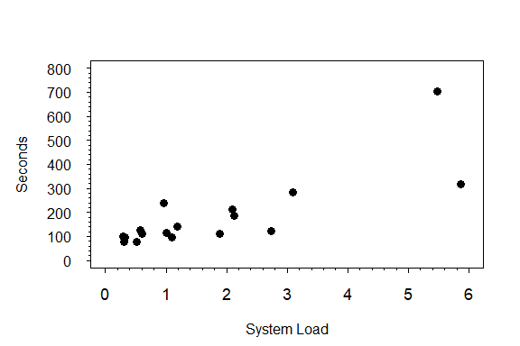

```r
censored.data.plot(comptime.ld,
                   xlab = "System Load")
```

comptime.mlest.out <- groupm.mleprobplot(comptime.ld, distribution =“Lognormal”, group.var = 1, relationship = “linear”)

comptime.mlest.out2 <- groupm.mleprobplot(comptime.ld, distribution =“Normal”, group.var = 1, relationship = “linear”)

resid.vs.order(comptime.mlest.out)

resid.vs.fit(comptime.mlest.out)

resid.vs.explan(comptime.mlest.out)

resid.probplot(comptime.mlest.out)

plot(comptime.mlest.out, density.at = c(1, 3, 5))

plot(comptime.mlest.out, density.at = c(1, 3, 5),response.on.yaxis = F)

# or more simply as

plot(comptime.mlest.out)

quantiles(comptime.mlest.out,new.data=5)

# Example x Snubber data set

Snubber.ld <- frame.to.ld(snubber, response.column = “cycles”, censor.column = “event”, time.units = “Cycles”, case.weight.column = “count”, x.columns = “design”)

event.plot(Snubber.ld) summary(Snubber.ld)

Snubber.groupi.nor.out <- groupi.mleprobplot(Snubber.ld,“normal”)

tmpxx <- groupi.contour(Snubber.ld,“Weibull”,the.quantile=.1) tmpxx <- groupi.contour(Snubber.ld,“lognormal”,the.quantile=.1) tmpxx <- groupi.contour(Snubber.ld,“lognormal”) tmpxx <- groupi.contour(Snubber.ld,“normal”) tmpxx <- groupi.contour(Snubber.ld,“normal”,the.quantile=.1) multiple.profile.plot(tmpxx, which = “x”) multiple.profile.plot(tmpxx, which = “y”)

summary(Snubber.groupi.nor.out)

Snubber.groupm.nor.out <- groupm.mleprobplot(Snubber.ld,distribution=“Normal”,relationship=“class”)

quantiles(Snubber.groupm.nor.out,new.data=“Old”) quantiles(Snubber.groupm.nor.out,new.data=“New”)

plot(Snubber.groupm.nor.out)

PartA.ld <- frame.to.ld(parta, response.column = “kcycles”, x.columns = “operator”)

groupi.contour(PartA.ld,rel.or.conf=“”,“Weibull”,the.quantile = 0.10) groupi.contour(PartA.ld,“Weibull”,the.quantile = 0.10)

groupi.contour(PartA.ld,rel.or.conf=“”,“Weibull”,the.quantile = 0.005) groupi.contour(PartA.ld,“Weibull”,the.quantile = 0.005)

# Zelen capacator data

```r
ZelenCap.ld <- frame.to.ld(zelencap,
                           response.column = 1,
                           censor.column = 2,
                           case.weight.column = 3,
                           x.columns = c(4, 5),
                           time.units = "Hours")
```

## Fitting distributions at individual conditions

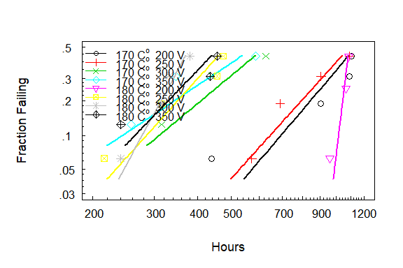

```r
ZelenCap.groupi.Weibull.out <-
  groupi.mleprobplot(ZelenCap.ld,
                     distribution = "Weibull",
                     group.var = c(1, 2))
```

```r
summary(ZelenCap.groupi.Weibull.out)
```

```
Maximum likelihood estimation results:
Response units: Hours

Weibull Distribution
                Group Log likelihood     mu  se_mu  sigma se_sigma
1 170celsius;200volts         -31.78 1253.3 186.94  3.797   1.8156
2 170celsius;250volts         -31.69 1209.6 187.51  3.579   1.6356
3 170celsius;300volts         -30.16  716.4 147.42  2.685   1.2137
4 170celsius;350volts         -30.34  690.9 177.04  2.153   0.9697
5 180celsius;200volts         -24.85 1104.7  23.16 26.991  12.8393
6 180celsius;250volts         -28.44  533.6  83.11  3.587   1.6725
7 180celsius;300volts         -25.99  405.0  38.01  5.939   2.7349
8 180celsius;350volts         -28.42  515.9  85.45  3.356   1.5520

Total log likelihood= -231.7
```

```r
names(xmat(ZelenCap.ld))
```

```
[1] "celsius" "volts"
```

Constrain the Weibull shape parameters to be the same - like one-way ANOVA

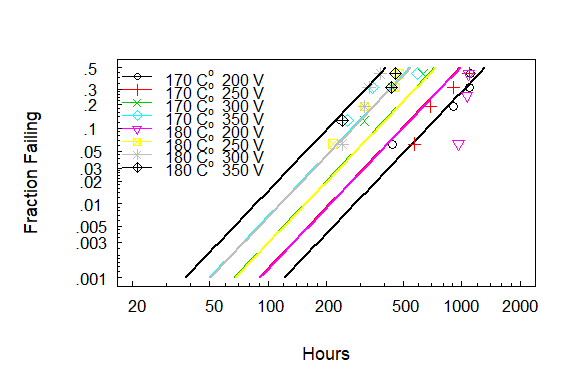

```r
ZelenCap.groupm.out1 <-
  groupm.mleprobplot(ZelenCap.ld,
                     distribution = "Weibull")
```

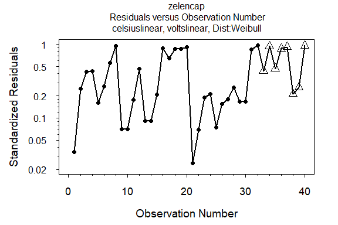

```r
resid.vs.order(ZelenCap.groupm.out1)
```

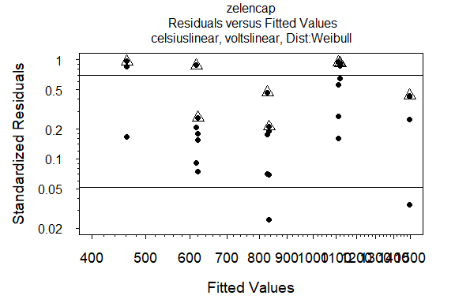

```r
resid.vs.fit(ZelenCap.groupm.out1)
```

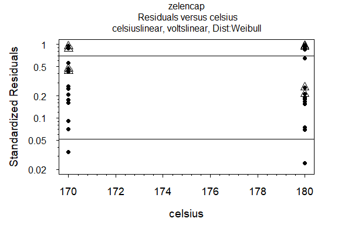

```r
resid.vs.explan(ZelenCap.groupm.out1,
                x.to.plot = 1)
```

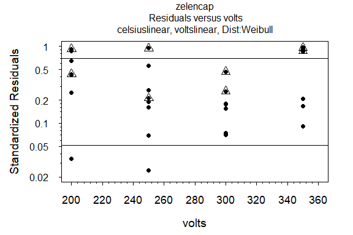

```r
resid.vs.explan(ZelenCap.groupm.out1,
                x.to.plot = 2)
```

```r
#resid.probplot(ZelenCap.groupm.out1)
```

## Fitting to `celsius` only

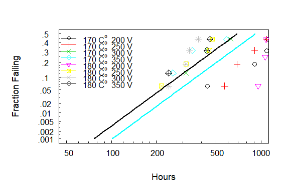

```r
ZelenCap.groupm.out2 <-
  groupm.mleprobplot(ZelenCap.ld,
                     distribution = "Lognormal",
                     formula= Location ~ + g(celsius),
                     relationship = c("arrhenius", "log"))
```

## Fitting to `volts` only

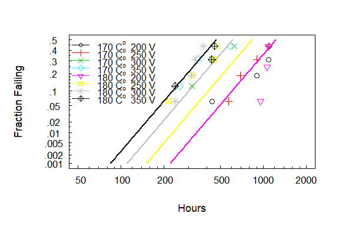

```r
ZelenCap.groupm.out3 <-
  groupm.mleprobplot(ZelenCap.ld,
                     distribution = "Lognormal",
                     formula= Location ~ + g(volts),
                     relationship = c("arrhenius", "log"))
```

## Fitting to `celsius` and `volts`

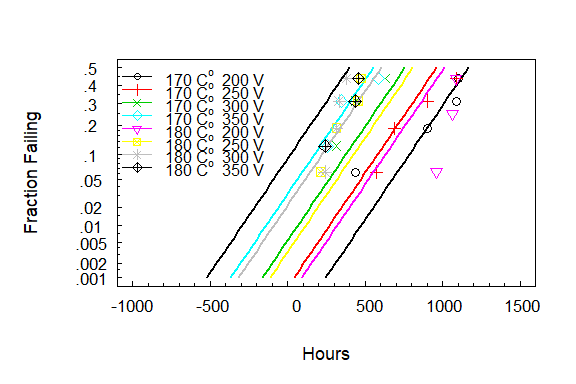

```r
ZelenCap.groupm.out4 <-
  groupm.mleprobplot(ZelenCap.ld,
                     distribution = "normal",
                     formula = Location ~ + g(celsius) +  g(volts))
```

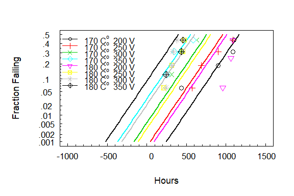

```r
ZelenCap.groupm.out5 <-
  groupm.mleprobplot(ZelenCap.ld,
                     distribution = "normal",
                     formula= Location ~  +  g(volts) + g(celsius))
```

## Fitting to `volts` and `celsius` with interaction

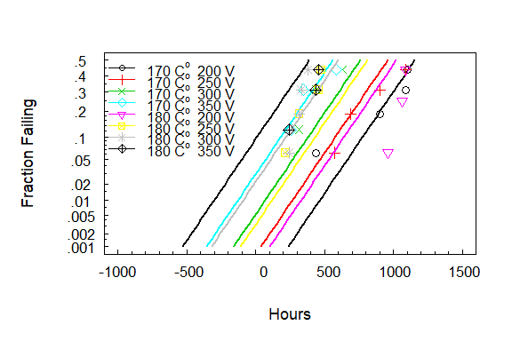

```r
ZelenCap.groupm.out6 <-
  groupm.mleprobplot(ZelenCap.ld,
                     distribution = "normal",
                     formula = Location ~ celsius + volts + celsius:volts )
```

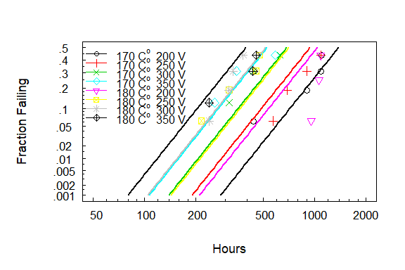

```r
ZelenCap.groupm.out7 <-
  groupm.mleprobplot(ZelenCap.ld,
                     distribution = "Lognormal",
                     relationship=c("arrhenius","log"))
```

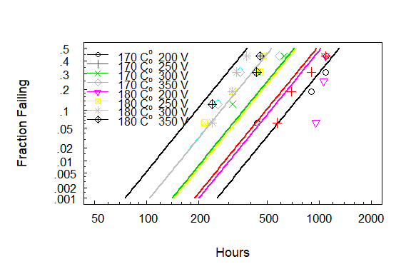

```r
ZelenCap.groupm.out3 <-
  groupm.mleprobplot(ZelenCap.ld,
                     distribution = "Lognormal",
                     relationship = c("linear", "linear"),
                     formula = Location ~ + g(volts) + g(celsius) + g(volts):g(celsius))
```

```r
#make a proper dataframe for new data (used below)
frame.new.data("165;188",ZelenCap.groupm.out3[[1]])

#temperature and voltage need be in the right order, semicolon separated
quantiles(ZelenCap.groupm.out3,new.data="165;188")

failure.probabilities(ZelenCap.groupm.out3,new.data="165;188")



resid.vs.explan.multiple(ZelenCap.groupm.out3)
residual.plots(ZelenCap.groupm.out3)
```

# Example 7 Nelson’s Superalloy Fatigue vs Stress Data

```r
superalloy.ld <- frame.to.ld(superalloy,
                             response.column = 1,
                             censor.column = 2,
                             x.columns = c(4,5,6),
                             data.title = "Nelson's Super Alloy Fatigue Data",
                             time.units = "Kilocycles")

summary(superalloy.ld)
```

```
Summary of: Nelson's Super Alloy Fatigue Data



Number of rows in data matrix= 26
Response units:  Kilocycles
Response minimum:  5.733
Response maximum:  211.63
Number of cases in data set= 26
Number of exact observations in data set= 22
Number of right censored observations in data set= 4
No truncation information

Summary of numeric columns in X matrix:
              min      max     mean       sd       cv
pstress   80.3000 145.9000 102.4654 20.68201 0.201844
lpstress   4.3858   4.9829   4.6112  0.19192 0.041620
lpstress2 19.2350  24.8295  21.2988  1.79116 0.084096

List of unique X values (or combinations)
   pstress lpstress lpstress2 min-Resp max-Resp #Exact #R-cen Total
1    145.9   4.9829    24.830    5.733    5.733      1      0     1
2     85.2   4.4450    19.758   13.949   13.949      1      0     1
3    116.4   4.7570    22.629   15.616   15.616      1      0     1
4     87.2   4.4682    19.965   56.723   56.723      1      0     1
5    100.1   4.6062    21.217   12.076   12.076      1      0     1
6     85.8   4.4520    19.820  152.680  152.680      1      0     1
7     99.8   4.6032    21.189   43.331   43.331      1      0     1
8    113.0   4.7274    22.348   18.067   18.067      1      0     1
9    120.4   4.7908    22.952    9.750    9.750      1      0     1
10    86.4   4.4590    19.883  156.725  156.725      1      0     1
11    85.6   4.4497    19.800  112.968  112.968      0      1     1
12    86.7   4.4624    19.913  138.114  138.114      0      1     1
13    89.7   4.4965    20.218  122.372  122.372      0      1     1
14   114.8   4.7432    22.498   21.300   21.300      1      0     1
15   144.5   4.9733    24.734    6.705    6.705      1      0     1
16    91.3   4.5141    20.378  112.002  112.002      1      0     1
17   142.5   4.9593    24.595   11.865   11.865      1      0     1
18   100.5   4.6102    21.254   13.181   13.181      1      0     1
19   118.4   4.7741    22.792    8.489    8.489      1      0     1
20   118.6   4.7758    22.808   12.434   12.434      1      0     1
21   118.0   4.7707    22.759   13.030   13.030      1      0     1
22    80.8   4.3920    19.289   57.923   57.923      0      1     1
23    87.3   4.4694    19.975  121.075  121.075      1      0     1
24    80.6   4.3895    19.268  200.027  200.027      1      0     1
25    80.3   4.3858    19.235  211.629  211.629      1      0     1
26    84.3   4.4344    19.664  155.000  155.000      1      0     1
```

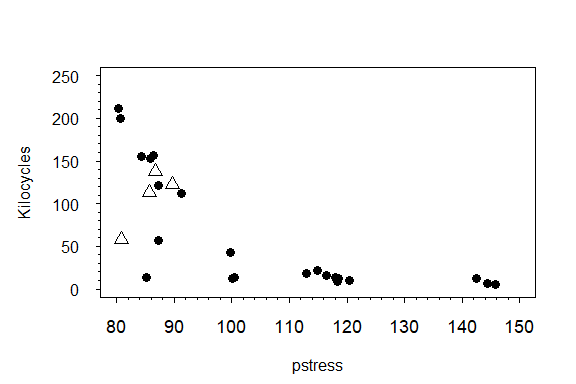

```r
censored.data.plot(superalloy.ld)
```

# Fitting a model with NON-CONSTANT variance

The following code is used to fit a regression model with a non-constant variance where the 2nd and 3rd col of the model matrix are `LogStress` and `LogStress2`. Note that this is not working right now and may cause R to crash - not clear why.

```r
gmlest(superalloy.ld,
       dist = "Weibull",
       explan.vars = list(mu.relat=c(2,3),
                          sigma.relat=c(2)))
```

We can use the following to prepare new.data from a string

```r
frame.new.data("165;150",ZelenCap.groupm.out3[[1]])
```